# Pingüinos de Adelia

Miriam Lerma

29/3/2021

# 1 Introducción

Los pingüinos de Adelia (*Pygoscelis adeliae*) son una especie protegida y no sabemos si están perdiendo peso conforme se calienta el océano y se reduce la disponibilidad de alimento para ésta especie.  
Se pueden instalar cámaras en las colonias para tomarles fotos de manera regular. Las cámaras registran bien la longitud de aleta.

- El objetivo de este estudio es evaluar si la medida de la aleta se puede usar para predecir el peso de los pingüinos.

# 2 Métodos

Se usaron datos de pingüinos de Adelia (*Pygoscelis adeliae*) para explorar la relación entre peso y largo de la aleta obtenidos de un estudio con pinguinos en la Antarctica (Gorman, Williams, and Fraser 2014).  
La limpieza de los datos se hizo usando funciones de tidyverse Wickham et al. (2019)

```r
#Asi cargo mis datos de pinguinos
#remotes::install_github("cienciadedatos/datos")
library(datos)
Pingus<-pinguinos
library(tidyverse)
Adelia<-Pingus%>%
  filter(especie=='Adelia')%>%
  drop_na()
```

Se colectaron un total de 146 muestras correspondientes a pingüinos de Adelia.

Se creo un modelo linear para ver la relacion entre el peso y el largo de la aleta.

```r
lm_Adelia<-lm(data=Adelia,masa_corporal_g ~ largo_aleta_mm) #crea el modelo
TablaResultados<-broom::tidy(lm_Adelia)#crea la tabla
```

# 3 Resultados

Encontramos una relación positiva entre la masa corporal y el largo de la aleta en los pingüinos de Adelia (Tabla 2, Fig. 2).

```r
library(kableExtra)
kbl(TablaResultados,
    booktabs = T, caption = "Tabla 2. Resultado del modelo de regresion") %>% #Titulo
    kable_styling(latex_options = c("striped", "hold_position"),
                full_width = F)
```

Tabla 2. Resultado del modelo de regresion

| term | estimate | std.error | statistic | p.value |
| --- | --- | --- | --- | --- |
| (Intercept) | -2508.08774 | 986.911300 | -2.541351 | 0.0121011 |
| largo_aleta_mm | 32.68891 | 5.188431 | 6.300346 | 0.0000000 |

**Fig 2**. Masa corporal y largo de aleta en pingüinos de Adelia.

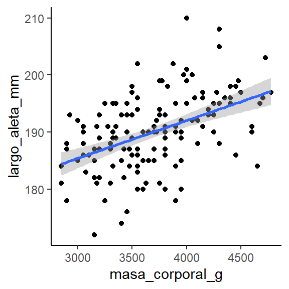

```r
ggplot(Adelia, aes(x=masa_corporal_g, y=largo_aleta_mm))+
  geom_point()+
  geom_smooth(method="lm")+
  theme_classic()
```

# 4 Discusión

Se puede predecir el peso de los pingüinos de Adelia al medirles la aleta usando la formula (Masa corporal = 32.6889141 x Largo de aleta -2508.0877429).

# 5 Conclusión

Las camaras pueden ser utiles para evaluar cambios en el peso de los pingüinos de Adelia.

# Referencias

Gorman, Kristen B, Tony D Williams, and William R Fraser. 2014. “Ecological Sexual Dimorphism and Environmental Variability Within a Community of Antarctic Penguins (Genus Pygoscelis).” *PloS One* 9 (3): e90081.

Wickham, Hadley, Mara Averick, Jennifer Bryan, Winston Chang, Lucy D’Agostino McGowan, Romain François, Garrett Grolemund, et al. 2019. “Welcome to the tidyverse.” *Journal of Open Source Software* 4 (43): 1686. https://doi.org/10.21105/joss.01686.